# FINAL2-Copy3

```python
import pandas as pd
import seaborn as sns
import statsmodels.formula.api as smf
from sklearn.linear_model import LinearRegression
from sklearn import metrics
from sklearn.model_selection  import train_test_split
import numpy as np
from sklearn.metrics import accuracy_score, f1_score, confusion_matrix, recall_score,classification_report
%matplotlib inline
```

```python
df=pd.read_csv('creditcard.csv', sep=',')
```

```python
df.head(5)
```

|  | Time | V1 | V2 | V3 | V4 | V5 | V6 | V7 | V8 | V9 | ... | V21 | V22 | V23 | V24 | V25 | V26 | V27 | V28 | Amount | Class |
| --- | --- | --- | --- | --- | --- | --- | --- | --- | --- | --- | --- | --- | --- | --- | --- | --- | --- | --- | --- | --- | --- |
| 0 | 0.0 | -1.359807 | -0.072781 | 2.536347 | 1.378155 | -0.338321 | 0.462388 | 0.239599 | 0.098698 | 0.363787 | ... | -0.018307 | 0.277838 | -0.110474 | 0.066928 | 0.128539 | -0.189115 | 0.133558 | -0.021053 | 149.62 | 0 |
| 1 | 0.0 | 1.191857 | 0.266151 | 0.166480 | 0.448154 | 0.060018 | -0.082361 | -0.078803 | 0.085102 | -0.255425 | ... | -0.225775 | -0.638672 | 0.101288 | -0.339846 | 0.167170 | 0.125895 | -0.008983 | 0.014724 | 2.69 | 0 |
| 2 | 1.0 | -1.358354 | -1.340163 | 1.773209 | 0.379780 | -0.503198 | 1.800499 | 0.791461 | 0.247676 | -1.514654 | ... | 0.247998 | 0.771679 | 0.909412 | -0.689281 | -0.327642 | -0.139097 | -0.055353 | -0.059752 | 378.66 | 0 |
| 3 | 1.0 | -0.966272 | -0.185226 | 1.792993 | -0.863291 | -0.010309 | 1.247203 | 0.237609 | 0.377436 | -1.387024 | ... | -0.108300 | 0.005274 | -0.190321 | -1.175575 | 0.647376 | -0.221929 | 0.062723 | 0.061458 | 123.50 | 0 |
| 4 | 2.0 | -1.158233 | 0.877737 | 1.548718 | 0.403034 | -0.407193 | 0.095921 | 0.592941 | -0.270533 | 0.817739 | ... | -0.009431 | 0.798278 | -0.137458 | 0.141267 | -0.206010 | 0.502292 | 0.219422 | 0.215153 | 69.99 | 0 |

5 rows × 31 columns

```python
print(df.shape)
```

```
(284807, 31)
```

This dataset presents transactions that occurred in two days, we have total 284807 transactions.It contains only numerical input variables which are the result of a PCA transformation. Unfortunately, due to confidentiality issues,they cannot provide the original features and more background information about the data. Features V1, V2, … V28 are the principal components obtained with PCA, the only features which have not been transformed with PCA are 'Time' and 'Amount'. Feature 'Time' contains the seconds elapsed between each transaction and the first transaction in the dataset. The feature 'Amount' is the transaction Amount, this feature can be used for example-dependant cost-senstive learning. Feature 'Class' is the response variable and it takes value 1 in case of fraud and 0 otherwise. What is PCA:: The main idea of principal component analysis (PCA) is to reduce the dimensionality of a data set consisting of many variables correlated with each other, either heavily or lightly, while retaining the variation present in the dataset, up to the maximum extent. The same is done by transforming the variables to a new set of variables, which are known as the principal components or simply, the PCs.

Let see how many of the Normal and fraud cases are present in this dataset.

```python
class_names = {0:'Normal', 1:'Fraud'}
print(df.Class.value_counts().rename(index = class_names))
```

```
Normal    284315
Fraud        492
Name: Class, dtype: int64
```

```python
from sklearn.preprocessing import StandardScaler
df['Amount_new'] = StandardScaler().fit_transform(df['Amount'].values.reshape(-1, 1))
df = df.drop(['Time', 'Amount'], axis=1)
df.head()
```

|  | V1 | V2 | V3 | V4 | V5 | V6 | V7 | V8 | V9 | V10 | ... | V21 | V22 | V23 | V24 | V25 | V26 | V27 | V28 | Class | Amount_new |
| --- | --- | --- | --- | --- | --- | --- | --- | --- | --- | --- | --- | --- | --- | --- | --- | --- | --- | --- | --- | --- | --- |
| 0 | -1.359807 | -0.072781 | 2.536347 | 1.378155 | -0.338321 | 0.462388 | 0.239599 | 0.098698 | 0.363787 | 0.090794 | ... | -0.018307 | 0.277838 | -0.110474 | 0.066928 | 0.128539 | -0.189115 | 0.133558 | -0.021053 | 0 | 0.244964 |
| 1 | 1.191857 | 0.266151 | 0.166480 | 0.448154 | 0.060018 | -0.082361 | -0.078803 | 0.085102 | -0.255425 | -0.166974 | ... | -0.225775 | -0.638672 | 0.101288 | -0.339846 | 0.167170 | 0.125895 | -0.008983 | 0.014724 | 0 | -0.342475 |
| 2 | -1.358354 | -1.340163 | 1.773209 | 0.379780 | -0.503198 | 1.800499 | 0.791461 | 0.247676 | -1.514654 | 0.207643 | ... | 0.247998 | 0.771679 | 0.909412 | -0.689281 | -0.327642 | -0.139097 | -0.055353 | -0.059752 | 0 | 1.160686 |
| 3 | -0.966272 | -0.185226 | 1.792993 | -0.863291 | -0.010309 | 1.247203 | 0.237609 | 0.377436 | -1.387024 | -0.054952 | ... | -0.108300 | 0.005274 | -0.190321 | -1.175575 | 0.647376 | -0.221929 | 0.062723 | 0.061458 | 0 | 0.140534 |
| 4 | -1.158233 | 0.877737 | 1.548718 | 0.403034 | -0.407193 | 0.095921 | 0.592941 | -0.270533 | 0.817739 | 0.753074 | ... | -0.009431 | 0.798278 | -0.137458 | 0.141267 | -0.206010 | 0.502292 | 0.219422 | 0.215153 | 0 | -0.073403 |

5 rows × 30 columns

As this is a imbalance dataset we are using SMOTE(Synthetic Minority Oversampling Technique) A problem with imbalanced classification is that there are too few examples of the minority class for a model to effectively learn the decision boundary.One way to solve this problem is to oversample the examples in the minority class. This can be achieved by simply duplicating examples from the minority class in the training dataset prior to fitting a model. This can balance the class distribution but does not provide any additional information to the model.An improvement on duplicating examples from the minority class is to synthesize new examples from the minority class. This is a type of data augmentation for tabular data and can be very effective.

```python
conda install -c conda-forge imbalanced-learn
```

```
Solving environment: ...working... done

# All requested packages already installed.
```

Here we are spliting dataset to 80/20 traning and test data.

```python
from imblearn.over_sampling import SMOTE
from sklearn.model_selection  import train_test_split
X = df.drop(['Class'],axis=1)
Y = df['Class']
X_train, X_test, Y_train, Y_test = train_test_split(X, Y, test_size=0.2)
```

```python
print("Number transactions X_train dataset: ", X_train.shape)
print("Number transactions Y_train dataset: ", Y_train.shape)
print("Number transactions X_test dataset: ", X_test.shape)
print("Number transactions Y_test dataset: ", Y_test.shape)
```

[output not shown]

Applying smote for traning datasets.

```python
sm = SMOTE(random_state=27, ratio=1.0)
```

```python
X_train, Y_train = sm.fit_sample(X_train, Y_train)
```

smote has marked up the traning samples for more balancing and better results.

```python
print("Number transactions X_train dataset: ", X_train.shape)
print("Number transactions Y_train dataset: ", Y_train.shape)
```

```
Number transactions X_train dataset:  (454890, 30)
Number transactions Y_train dataset:  (454890,)
```

MODEL FITTING: As our dataset is now more balanced and standized we will try some modeling algorithms and check the results as confusion matrix and clsification reports.

MODEL 1 : Logistic Regression: Logistic regression is the appropriate regression analysis to conduct when the dependent variable is dichotomous (binary). Like all regression analyses, the logistic regression is a predictive analysis. Logistic regression is used to describe data and to explain the relationship between one dependent binary variable and one or more nominal, ordinal, interval or ratio-level independent variables.Logistic regression is used in various fields, including machine learning, most medical fields, and social sciences. For example, the Trauma and Injury Severity Score (TRISS), which is widely used to predict mortality in injured patients, was originally developed by Boyd et al. using logistic regression.Many other medical scales used to assess severity of a patient have been developed using logistic regression. In economics it can be used to predict the likelihood of a person's choosing to be in the labor force, and a business application would be to predict the likelihood of a homeowner defaulting on a mortgage. Conditional random fields, an extension of logistic regression to sequential data, are used in natural language processing. One of the main reason for using logistic regression here is that we have a binary dependent variable and LR works very nicely in thsese cases as explained above.

```python
import sklearn.linear_model as sk
LR = sk.LogisticRegression(solver='liblinear').fit(X_train, Y_train)
LR_pred = LR.predict(X_test)
```

```python
accuracy_score(Y_test, LR_pred)
```

```
0.9843228819212808
```

```python
f1_score(Y_test, LR_pred)
```

```
0.1599247412982126
```

We are ploting a confusion matrix for our test dataset to see how LR works

```
[[55984   886]
 [    7    85]]
```

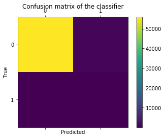

```python
from sklearn.metrics import confusion_matrix
from matplotlib import pyplot as plt
labels = ['0', '1']
LR = confusion_matrix(Y_test, LR_pred)
print(LR)
fig = plt.figure()
ax = fig.add_subplot(111)
cax = ax.matshow(LR)
plt.title('Confusion matrix of the classifier')
fig.colorbar(cax)
ax.set_xticklabels([''] + labels)
ax.set_yticklabels([''] + labels)
plt.xlabel('Predicted')
plt.ylabel('True')
plt.show()
```

Before we discuss the result of confusion here is a bit about confusion matrix A confusion matrix is a table that is often used to describe the performance of a classification model (or "classifier") on a set of test data for which the true values are known. The confusion matrix itself is relatively simple to understand, but the related terminology can be confusing true positives (TP): These are cases in which we predicted yes, and they are yes. true negatives (TN): We predicted no, and they are no. false positives (FP): We predicted yes, but they are no (Also known as a "Type I error.") false negatives (FN): We predicted no, but they are yes(Also known as a "Type II error.") Error Rate = FP+FN/N+P , The best error rate is 0.0, whereas the worst is 1.0. Accuracy = 1- error rate

Now we look at our results by confusion matrix. As per heat pattern above shows blue to yellow as the intence increases. yellow block shows the true positive cases. true positives (TP): 55984 true negatives (TN): 85 false positives (FP):886 (Also known as a "Type I error.") false negatives (FN): 7(Also known as a "Type II error.") We can detect 85 frauds out of 92 frauds. Error Rate = 0.015 Accuracy = 0.98

```python
recall_score(Y_test, LR_pred)
```

```
0.9239130434782609
```

To understand the results more we have also generated the classification report for your test dataset.Before we go further for results let's have a look for the concepts in classification report.

Precision – What percent of your predictions were correct? Precision is the ability of a classifier not to label an instance positive that is actually negative. For each class it is defined as the ratio of true positives to the sum of true and false positives. TP – True Positives FP – False Positives Precision – Accuracy of positive predictions. Precision = TP/(TP + FP)

Recall – What percent of the positive cases did you catch? Recall is the ability of a classifier to find all positive instances. For each class it is defined as the ratio of true positives to the sum of true positives and false negatives. FN – False Negatives Recall: Fraction of positives that were correctly identified. Recall = TP/(TP+FN)

F1 score – What percent of positive predictions were correct? The F1 score is a weighted harmonic mean of precision and recall such that the best score is 1.0 and the worst is 0.0. Generally speaking, F1 scores are lower than accuracy measures as they embed precision and recall into their computation. As a rule of thumb, the weighted average of F1 should be used to compare classifier models, not global accuracy. F1 Score = 2*(Recall* Precision) / (Recall + Precision) Support : Support is the number of actual occurrences of the class in the specified dataset

Lets print classification report for logistic regression

```python
print(classification_report(Y_test,LR_pred))
```

```
              precision    recall  f1-score   support

           0       1.00      0.98      0.99     56870
           1       0.09      0.92      0.16        92

    accuracy                           0.98     56962
   macro avg       0.54      0.95      0.58     56962
weighted avg       1.00      0.98      0.99     56962
```

MODEL 2 : Naive Bayes: Naive Bayes models are a group of extremely fast and simple classification algorithms that are often suitable for very high-dimensional datasets. Because they are so fast and have so few tunable parameters, they end up being very useful as a quick-and-dirty baseline for a classification problem and as this can be termed as classification problem so we are trying this algo. Naive Bayes classifiers are built on Bayesian classification methods. These rely on Bayes's theorem, which is an equation describing the relationship of conditional probabilities of statistical quantities.

```python
from sklearn.naive_bayes import GaussianNB
NB_classifier = GaussianNB()
NB= NB_classifier.fit(X_train, Y_train)
```

```python
NB_pred = NB.predict(X_test)
```

```python
print(classification_report(Y_test, NB_pred))
```

```
              precision    recall  f1-score   support

           0       1.00      0.99      1.00     56870
           1       0.15      0.86      0.25        92

    accuracy                           0.99     56962
   macro avg       0.57      0.93      0.62     56962
weighted avg       1.00      0.99      0.99     56962
```

Now lets see your results for Naive Bais for our dataset: Precision – 1.0 for normal and 0.15 for fraud cases Recall – 0.99 for normal and 0.86 for fraud cases F1 score – 1 for normal and .25 for fraud cases Support - 56870 normal and 92 fraud Accuracy - 0.99

lets see confusion matric for NB

[output not shown]

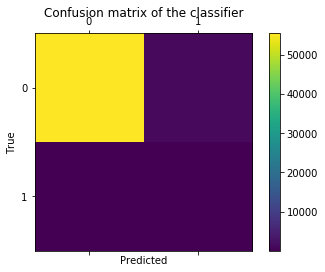

```python
from sklearn.metrics import confusion_matrix
import pylab as pl
from matplotlib import pyplot as plt
labels = ['0', '1']
NB_pred = confusion_matrix(Y_test, NB_pred)
print(NB_pred)
fig = plt.figure()
ax = fig.add_subplot(111)
cax = ax.matshow(NB_pred)
plt.title('Confusion matrix of the classifier')
fig.colorbar(cax)
ax.set_xticklabels([''] + labels)
ax.set_yticklabels([''] + labels)
plt.xlabel('Predicted')
plt.ylabel('True')
plt.show()
```

```python
df=df.sample(frac=.1,random_state=1)
df.shape
```

[output not shown]

MODEL3: Support Vector Machine Support Vector Machine” (SVM) is a supervised machine learning algorithm which can be used for both classification or regression challenges. However, it is mostly used in classification problems. In the SVM algorithm, we plot each data item as a point in n-dimensional space (where n is number of features you have) with the value of each feature being the value of a particular coordinate. Then, we perform classification by finding the hyper-plane that differentiates the two classes very well.Support Vectors are simply the co-ordinates of individual observation. The SVM classifier is a frontier which best segregates the two classes (hyper-plane/ line).We are using svm for our dataset to see if hyperplans approch can work with this dataset.

```python
from sklearn import svm
model = svm.SVC(kernel='rbf',decision_function_shape='ovr',max_iter=9000)
SV= model.fit(X_train,Y_train)
SV_pred= SV.predict(X_test)
```

Generating classification report

```python
print(classification_report(Y_test, SV_pred))
```

```
              precision    recall  f1-score   support

           0       0.98      0.02      0.05     56866
           1       0.00      0.76      0.00        96

    accuracy                           0.02     56962
   macro avg       0.49      0.39      0.02     56962
weighted avg       0.98      0.02      0.05     56962
```

Now lets see your results for SVM for our dataset: Precision – 0.98 for normal and 0.00 for fraud cases Recall – 0.02 for normal and 0.76 for fraud cases F1 score – 0.05 for normal and .00 for fraud cases Support - 56866 normal and 96 fraud Accuracy - 0.02

Lets see confusion matrix for SVM

```
[[ 1337 55529]
 [   23    73]]
```

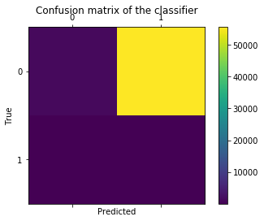

```python
from sklearn.metrics import confusion_matrix
import pylab as pl
from matplotlib import pyplot as plt
labels = ['0', '1']
SV_pred = confusion_matrix(Y_test, SV_pred)
print(SV_pred)
fig = plt.figure()
ax = fig.add_subplot(111)
cax = ax.matshow(SV_pred)
plt.title('Confusion matrix of the classifier')
fig.colorbar(cax)
ax.set_xticklabels([''] + labels)
ax.set_yticklabels([''] + labels)
plt.xlabel('Predicted')
plt.ylabel('True')
plt.show()
```

MODEL:4 Random Forest

Random Forest is a versatile machine learning method capable of performing both regression and classification tasks. It also undertakes dimensional reduction methods, treats missing values, outlier values and other essential steps of data exploration, and does a fairly good job.In Random Forest, we grow multiple trees as opposed to a single tree in CART model. To classify a new object based on attributes, each tree gives a classification and we say the tree “votes” for that class. The forest chooses the classification having the most votes (over all the trees in the forest) and in case of regression, it takes the average of outputs by different trees.One of benefits of Random forest is the power of handle large data set with higher dimensionality. It can handle thousands of input variables and identify most significant variables so it is considered as one of the dimensionality reduction methods. Further, the model outputs Importance of variable, which can be a very handy feature. we have a large dataset with many variables and that is the reason we are using random forst here.

lets apply random forest

```python
from sklearn.ensemble import RandomForestClassifier

R = RandomForestClassifier(n_estimators=100,
                               bootstrap = True,
                               max_features = 'sqrt')

RF= R.fit(X_train,Y_train)
RF_pred = RF.predict(X_test)
```

generate classification report

```python
print(classification_report(Y_test, RF_pred))
```

```
              precision    recall  f1-score   support

           0       1.00      1.00      1.00     56866
           1       0.88      0.81      0.84        96

    accuracy                           1.00     56962
   macro avg       0.94      0.91      0.92     56962
weighted avg       1.00      1.00      1.00     56962
```

Now lets see your results for Random forest for our dataset: Precision – 1.0 for normal and 0.88 for fraud cases Recall – 1.0 for normal and 0.81 for fraud cases F1 score – 1.0 for normal and 0.84 for fraud cases Support - 56866 normal and 96 fraud Accuracy - 1.0

lets gererate confusion matrix for RF

```
[[56855    11]
 [   18    78]]
```

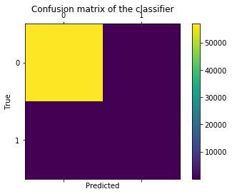

```python
from sklearn.metrics import confusion_matrix
import pylab as pl
from matplotlib import pyplot as plt
labels = ['0', '1']
RF_pred = confusion_matrix(Y_test, RF_pred)
print(RF_pred)
fig = plt.figure()
ax = fig.add_subplot(111)
cax = ax.matshow(RF_pred)
plt.title('Confusion matrix of the classifier')
fig.colorbar(cax)
ax.set_xticklabels([''] + labels)
ax.set_yticklabels([''] + labels)
plt.xlabel('Predicted')
plt.ylabel('True')
plt.show()
```

MODEL5 : K-MEANS K-means clustering is one of the simplest and popular unsupervised machine learning algorithms. Typically, unsupervised algorithms make inferences from datasets using only input vectors without referring to known, or labelled, outcomes.the objective of K-means is simple: group similar data points together and discover underlying patterns. To achieve this objective, K-means looks for a fixed number (k) of clusters in a dataset.A cluster refers to a collection of data points aggregated together because of certain similarities.We’ll define a target number k, which refers to the number of centroids you need in the dataset. A centroid is the imaginary or real location representing the center of the cluster. Every data point is allocated to each of the clusters through reducing the in-cluster sum of squares. In other words, the K-means algorithm identifies k number of centroids, and then allocates every data point to the nearest cluster, while keeping the centroids as small as possible.The ‘means’ in the K-means refers to averaging of the data; that is, finding the centroid.To process the learning data, the K-means algorithm in data mining starts with a first group of randomly selected centroids, which are used as the beginning points for every cluster, and then performs iterative (repetitive) calculations to optimize the positions of the centroids.It halts creating and optimizing clusters when either:The centroids have stabilized — there is no change in their values because the clustering has been successful.The defined number of iterations has been achieved.

```python
from sklearn.cluster import KMeans
from sklearn.metrics import confusion_matrix

model = KMeans(n_clusters=2,random_state=0)
model.fit(X_train,Y_train)
KM_pred= model.predict(X_test)
```

generate classification report for Kmeans

```python
print(classification_report(Y_test, KM_pred))
```

```
              precision    recall  f1-score   support

           0       1.00      0.47      0.64     56870
           1       0.00      0.77      0.00        92

    accuracy                           0.47     56962
   macro avg       0.50      0.62      0.32     56962
weighted avg       1.00      0.47      0.63     56962
```

Now lets see your results for K mean for our dataset: Precision – 1.0 for normal and 0.00 for fraud cases Recall – 0.47 for normal and 0.77 for fraud cases F1 score – 0.64 for normal and 0.00 for fraud cases Support - 56870 normal and 92 fraud Accuracy - 0.47

lets generate cunfusion matrix for k mean

```
[[26487 30383]
 [   21    71]]
```

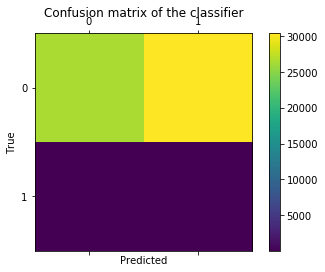

```python
from sklearn.metrics import confusion_matrix
import pylab as pl
from matplotlib import pyplot as plt
labels = ['0', '1']
KM_pred = confusion_matrix(Y_test, KM_pred)
print(KM_pred)
fig = plt.figure()
ax = fig.add_subplot(111)
cax = ax.matshow(KM_pred)
plt.title('Confusion matrix of the classifier')
fig.colorbar(cax)
ax.set_xticklabels([''] + labels)
ax.set_yticklabels([''] + labels)
plt.xlabel('Predicted')
plt.ylabel('True')
plt.show()
```

MODEL6: Minibatch K Means Mini Batch K-means algorithm‘s main idea is to use small random batches of data of a fixed size, so they can be stored in memory. Each iteration a new random sample from the dataset is obtained and used to update the clusters and this is repeated until convergence. Each mini batch updates the clusters using a convex combination of the values of the prototypes and the data, applying a learning rate that decreases with the number of iterations. This learning rate is the inverse of the number of data assigned to a cluster during the process. As the number of iterations increases, the effect of new data is reduced, so convergence can be detected when no changes in the clusters occur in several consecutive iterations. we are trying minibatch k means to see if it can improve the k means results.

```python
from sklearn.cluster import MiniBatchKMeans
from sklearn.metrics import confusion_matrix

model = MiniBatchKMeans(n_clusters=2,random_state=0)
model.fit(X_train,Y_train)
KMB_pred= model.predict(X_test)
```

Generating classification report

```python
print(classification_report(Y_test, KMB_pred))
```

```
              precision    recall  f1-score   support

           0       1.00      0.53      0.70     56870
           1       0.00      0.22      0.00        92

    accuracy                           0.53     56962
   macro avg       0.50      0.38      0.35     56962
weighted avg       1.00      0.53      0.69     56962
```

Now lets see your results for K mean for our dataset: Precision – 1.0 for normal and 0.00 for fraud cases Recall – 0.53 for normal and 0.22 for fraud cases F1 score – 0.70 for normal and 0.00 for fraud cases Support - 56870 normal and 92 fraud Accuracy - 0.53

lets generate confusion matrix for minibatch k mean

```
[[30400 26470]
 [   72    20]]
```

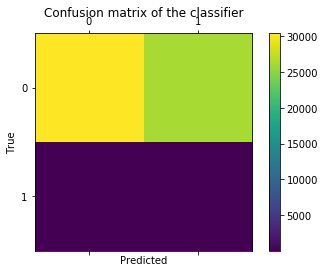

```python
from sklearn.metrics import confusion_matrix
import pylab as pl
from matplotlib import pyplot as plt
labels = ['0', '1']
KMB_pred = confusion_matrix(Y_test, KMB_pred)
print(KMB_pred)
fig = plt.figure()
ax = fig.add_subplot(111)
cax = ax.matshow(KMB_pred)
plt.title('Confusion matrix of the classifier')
fig.colorbar(cax)
ax.set_xticklabels([''] + labels)
ax.set_yticklabels([''] + labels)
plt.xlabel('Predicted')
plt.ylabel('True')
plt.show()
```

Now we look at our results by confusion matrix. As per heat pattern above shows blue to yellow as the intence increases. yellow block shows the true positive cases. true positives (TP): 30400 true negatives (TN): 20 false positives (FP):26470 (Also known as a "Type I error.") false negatives (FN): 72(Also known as a "Type II error.") We can detect 20 frauds out of 92 frauds. Error Rate= 0.46 Accuracy = 0.53

Conclusion: